# Data Science para Economía y Negocios - Laboratorio 1

17/3/2020

## Lab 01: Introducción a R

Contenidos:

- Presentación: **The R Project for Statistical Computing**
- Introducción **RStudio** y **RStudio Cloud**
- Aprende una nueva lengua, aprende R!!
  - Codificación orientada al objeto - tipos de objetos
  - Sintaxis
- Desmenuzando un código
- Tutoriales de R on-line: DataCamp!

## ¿Qué es R?

R es un software libre para la computación estadística y la generación de gráficos.

Cuando se aprende un nuevo idioma, las personas debemos aprender varias cosas como:

```
- Reglas de escritura
- Gramática
- Pronunciación
- Lectura, etc
```

De la misma forma, para aprender R, ud. debe aprender estas mismas reglas.

## ¿Qué es R?

[figure not shown]

## ¿Qué es R-Studio?

- R-Studio es un software IDE (Integrated Development Environment)
- Plataforma amigable ara la programación en R

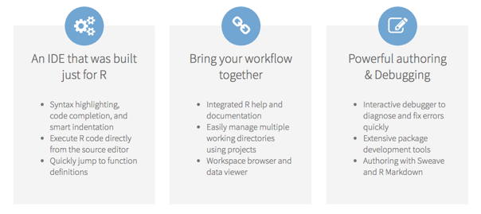

## ¿Qué es R-Studio Cloud?

- Una versión alojada de R-Studio en la nube
- No es necesario instalar software ni configurar nada desde el PC
- Solo deben crearse una cuenta y comenzar a utilizarlo!

## Programación basada en objetos

La programación basada en el objeto se enfoca en:

- Reunir datos del mundo y clasificarlo en objetos
- Utilizar esos objetos en distintas formas (funciones) para lograr extraer información relevante

Ejemplo:

- ¿Cómo sería la programación basada en el objeto de 3 tipos de perros?
  - Step1: ¿Cuál es el objeto?
  - Step2: ¿Cuáles son los atributos que definen el objeto?
  - Step3: ¿Qué cosas se pueden hacer en el objeto?

## Programación basada en objetos

[figure not shown]

## Lenguaje - Sintaxis 1: Comandos

¿Cómo se escribe en R?

- Comando: orden de un usuario que R ejecuta
  - Uno puede ejecutar un comando directamente en la Consola de R o bien en un Script (Source)
- R es case-sensitive, en general cualquier símbolo del alfabeto puede ser usado para nombrar un objeto
- El signo `<-` asigna a un valor a un objeto

## Lenguaje - Sintaxis 1: Comandos

- Un comando puede:
  - Correr algo en R (no crear nada)
  - Crear un objeto
  - Manipular un objeto
- En un script
  - Un comando por línea (recomendado)
  - Varios comandos por línea separados por “;”

## Lenguaje: Asignación y Objetos

¿Cómo se escribe en R?

- R se basa en data structres que son distintas formas de almacenar datos en objetos de distinta clase
- La creación de un objeto es la escencia de la programación en R y se hace a través de asignar valores a letras

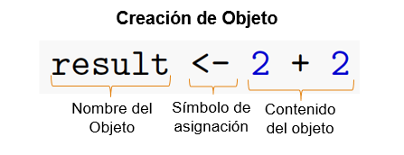

## Lenguaje - Sintaxis 2: Scripts

¿Cómo se escribe en R?

- Un script es una colección de órdenes ue un usuario le da a R para que se ejecuten
- Es una lista de tareas que se ejecutaran de forma cronológica
- Los scripts contienen:
  - Objetos, funciones y paquetes
- Reproductibilidad:
  - Capacidad de replicar un resultado o proceso. R es súper bueno en esto!!

## Lenguaje - Sintaxis 2: Scripts

Partes de un script:

```
- Metadatos: Información - ¿Qué hace el script? ¿Cuándo?
- Cargado de paquetes y seteo de directorios
- Lista de comandos
- Guardar resultados
```

## Lenguaje - Sintaxis 3: Objetos

Tipos de objetos en R

- Un objeto guarda datos, en el mundo hay múltiples tipos de datos, por ende hay muchos tipos de objetos!
- Los más comunes son:

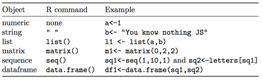

## Lenguaje - Sintaxis 3: Objetos

Partes de un objeto:

- Elementos: contenidos del objeto
- Atributos: otras características de los elementos del objeto

Dimensión de un objeto:

- Formas en la que los elementos se organizan dentro del objeto
  - Unidimensional - parámetros, vectores
  - Bidimensional - matrices, dataframes
  - Tridimensionales - arrys
  - N-dimensionales - listas

## Lenguaje - Sintaxis 4: Funciones

Funciones en R

- Una función es un conjunto de comandos compactados en un objeto
- Componentes:
  - Nombre
  - Paréntesis
  - Argumentos

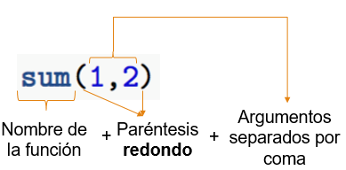

## Lenguaje - Sintaxis 4: Funciones

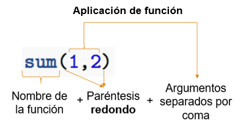

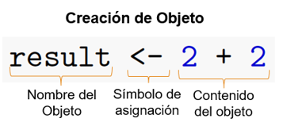

## Lenguaje - Sintaxis 4: Funciones

- Las funciones pueden servir como función última o como parte de un objetivo final
- Se pueden hacer objetos en base de funciones o como producto de ellas

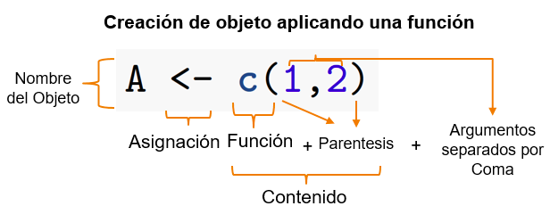

## Lenguaje - Sintaxis 5: Indexing

Indexar en R

¿Cómo busco/llamo un elemnto(s) específico dentro de un objeto?

- Respuesta: 2 Opciones
  - Por posición (manual)
  - Por condición (R busca la posición del elemento que cumple la condición)
- Sintaxis:
  - Indexar requiere el uso de corchetes [] justo después de un objeto
  - Si el objeto tiene más de una dimensión, se añade un “,” para separar cada dimensión

## Lenguaje - Sintaxis 5: Indexing

Indexando un objeto unidimensional

```r
A<-c(1,2)
A #entrega todos los elementos de A
```

```
## [1] 1 2
```

## Lenguaje - Sintaxis 5: Indexing

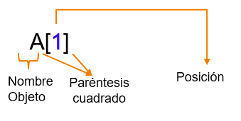

```r
A[1] #entrega el primer elemento de A
```

```
## [1] 1
```

```r
A[2] #entrega el segundo elemento de A
```

```
## [1] 2
```

## Lenguaje - Sintaxis 5: Indexing

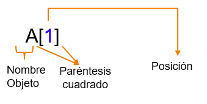

```r
A[-1] #entrega todos los elementos de A, menos el primero
```

```
## [1] 2
```

```r
A[1:2] #entrega el primer elemento de A hasta el segundo elemnto de A
```

```
## [1] 1 2
```

## Lenguaje - Sintaxis 5: Indexing

Indexando un objeto multidimensional

```r
B<-matrix(1:4,2,2)
B #entrega todos los elementos de B
```

```
##      [,1] [,2]
## [1,]    1    3
## [2,]    2    4
```

```r
B[1,2]
```

```
## [1] 3
```

```r
#entrega el elemento que se encuentra en la primera fila
#en la segunda columna
```

## Lenguaje – Sintaxis 6: Logical vectors

¿Cómo busco/llamo un elemnto(s) específico dentro de un objeto?

- Respuesta: 2 Opciones
  - Por posición (manual)
  - Por condición (R busca la posición del elemento que cumple la condición)

## Lenguaje – Sintaxis 6: Logical vectors

Por condición

Ejemplo 1:

Ejemplo 2:

- Objeto: Base de datos Asistentes del CEPR Workshop Series
- Pregunta: ¿Cuáles de ellos son de ing.civil?

## Lenguaje – Sintaxis 6: Logical vectors

Ejemplo 1:

Indexando objetos unidimensionales usando operaciones lógicas

```r
z<-c(3,2.1,4.55,3,9)
z
```

```
## [1] 3.00 2.10 4.55 3.00 9.00
```

Dime para cada elemento dentro de `z` si cumple la condición: el elemento es mayor o igual a 3

```r
z>=3
```

```
## [1]  TRUE FALSE  TRUE  TRUE  TRUE
```

## Lenguaje – Sintaxis 6: Logical vectors

Crear un nuevo ojbeto con todos los elementos de `z` que cumplan con la condición de ser mayores o iguales a 3

```r
q<-z[z>=3]
q
```

```
## [1] 3.00 4.55 3.00 9.00
```

## Lenguaje – Sintaxis 7: Object Manipulation

Funciones para recordar

- `class(x)`: revela el tipo de objeto e indirectamente dice que se puede hacer con él
- `lenght(x)`: revela la longitud de un objeto unidimensional
- `dim(X)`: revela la dimensión de un objeto n-dimensional
- `names(x)`: revela los nombres (si existen) de los elemntos de un objeto
- `attributes(x)`: revela todos los atributos de un objeto
- `rm(x)`: limina un objeto de la memoria de R, en una sesión
- `ls(x)`: revela todos los objetos en la memoria de R en una sesión específica